# Plots

# Plotting

marimo supports several popular plotting libraries, including matplotlib, plotly, seaborn, and altair.

This tutorial gives examples using matplotlib; other libraries are used similarly.

## Matplotlib

To show a plot, include it in the last expression of a cell (just like any other output).

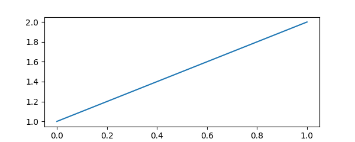

```python
# create the plot in the last line of the cell
import matplotlib.pyplot as plt
plt.plot([1, 2])
```

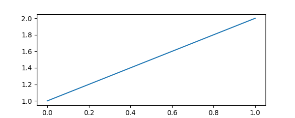

```python
# create a plot
plt.plot([1, 2])
# ... do some work ...
# make plt.gca() the last line of the cell
plt.gca()
```

You can use `plt.show()` or `figure.show()` to display plots in the console area of a cell. Keep in mind that console outputs are not shown in the app view.

**A new figure every cell.** Every cell starts with an empty figure for the imperative `pyplot` API.

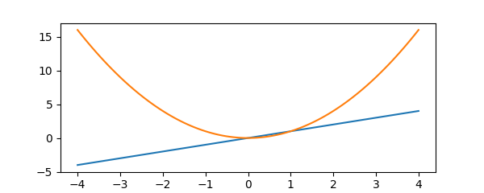

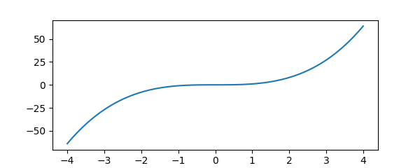

To build a figure over multiple cells, use the object-oriented API and create your own axis:

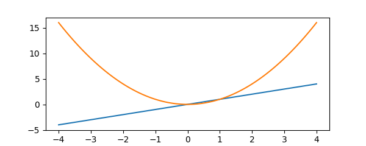

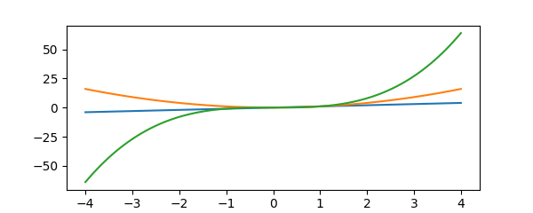

### Draw plots interactively

Draw plots interactively by parametrizing them with UI elements.

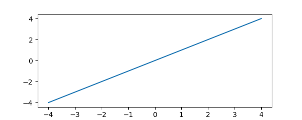

## Other libraries

marimo also supports these other plotting libraries:

- Plotly
- Seaborn
- Altair

Just output their figure objects as the last expression of a cell, or embed them in markdown with `mo.as_html`.

If you would like another library to be integrated into marimo, please get in touch.

Back to top